# Recursos básicos de visualização do R

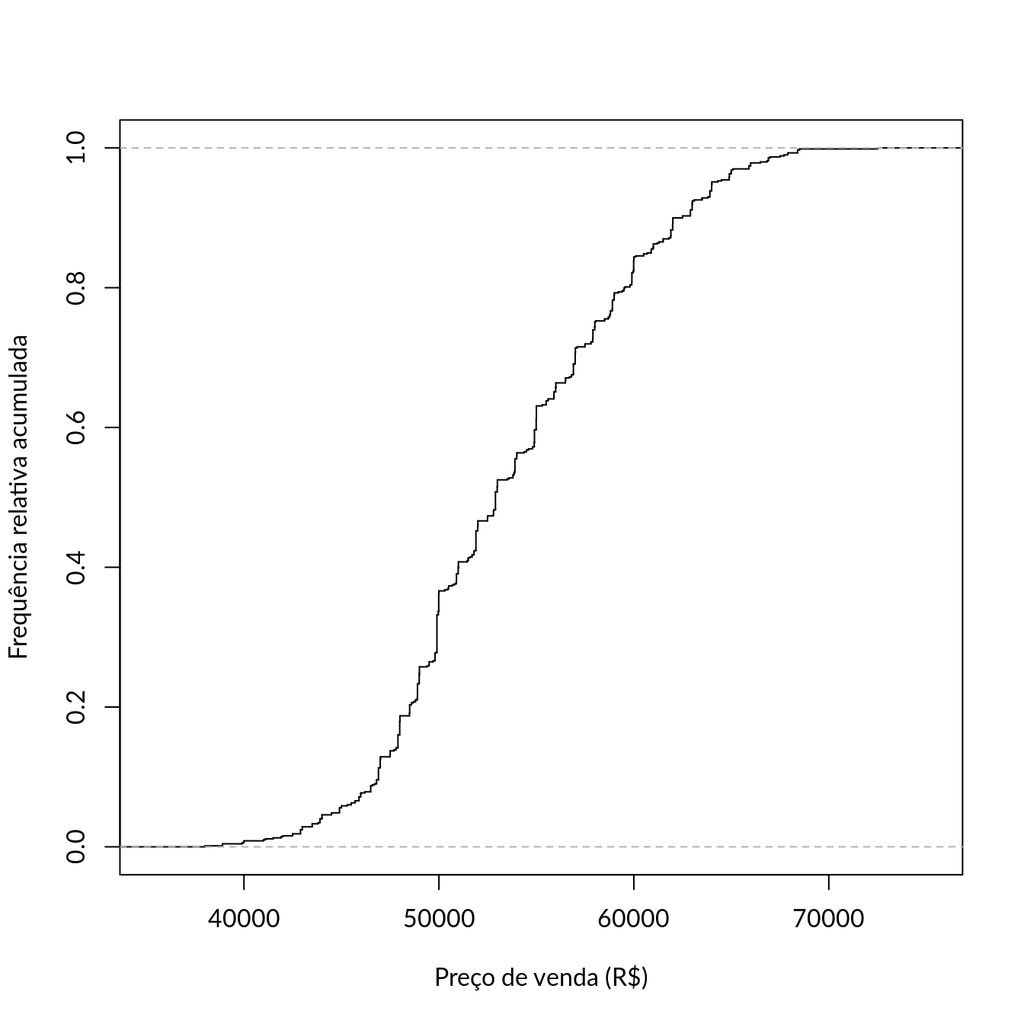

```r
plot(y,
     xlab = "Preço de venda (R$)",
     ylab = "Frequência relativa acumulada",
     cex = NA,
     verticals = TRUE,
     main = NULL)
```

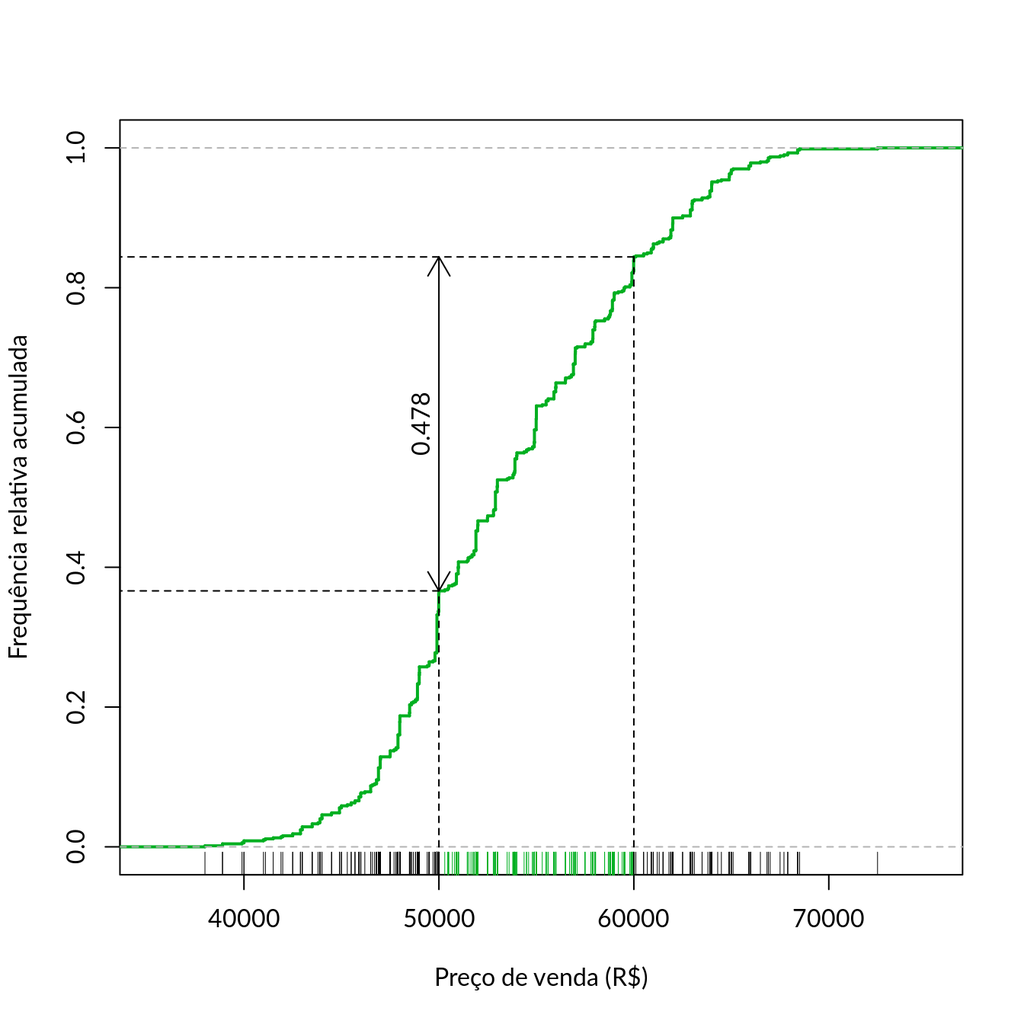

```r
# Destacando a frequência de veículos com preço de 50 à 60 mil.
lim <- c(50000, 60000)
ptbl <- prop.table(table(cut(dus$valor,
                             breaks = c(-Inf, lim, Inf))))
cs <- cumsum(ptbl)[seq_along(lim)]

# As observações do intervalo correspondem ao valor 1.
ins <- findInterval(dus$valor, vec = lim)
table(ins)
# ins
#   0   1   2
# 254 333 112

plot(y,
     xlab = "Preço de venda (R$)",
     ylab = "Frequência relativa acumulada",
     cex = NA,
     col = "#00af20",
     lwd = 2,
     verticals = TRUE,
     main = NULL)
segments(x0 = lim,
         y0 = 0,
         x1 = lim,
         y1 = cs,
         lty = 2)
segments(x0 = lim,
         y0 = cs,
         x1 = par()
         $usr[3],
         y1 = cs,
         lty = 2)
arrows(x0 = lim[1],
       y0 = cs[1],
       x1 = lim[1],
       y1 = cs[2],
       code = 3,
       length = 0.15)
text(x = lim[1],
     y = median(cs),
     labels = sprintf("%0.3f", ptbl[2]),
     srt = 90,
     adj = c(0.5,-0.5))
rug(dus$valor[ins == 1L], col = "#00af20")
rug(dus$valor[ins != 1L], col = "black")
```

# 6 Gráfico para duas variáveis contínuas

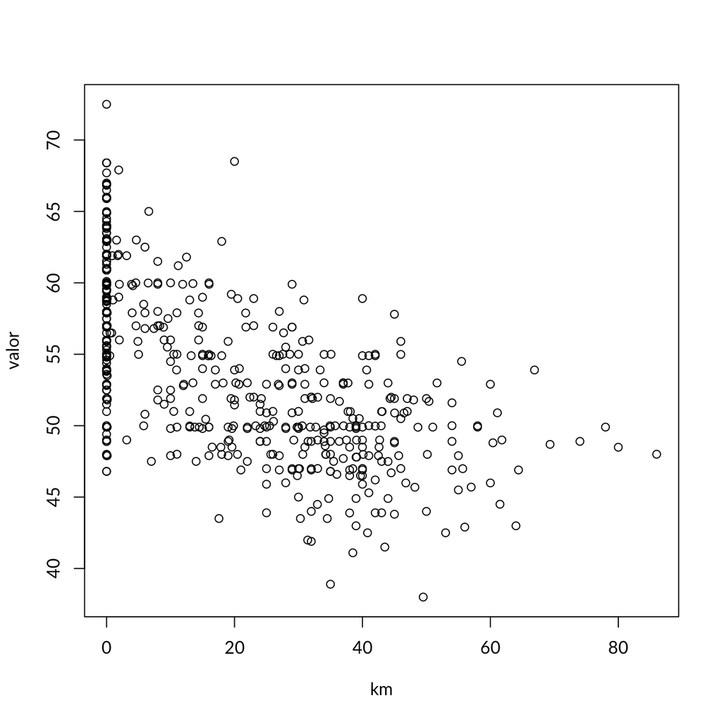

```r
#-----------------------------------------------------------------------
# Diagrama de dispersão.

dus2 <- subset(dus,
               complete.cases(cbind(km, valor)),
               select = c(cambio, valor, km))
dus2 <- transform(dus2, km = km/1000, valor = valor/1000)

# Diagrama de dispersão básico.
plot(valor ~ km, data = dus2)
```

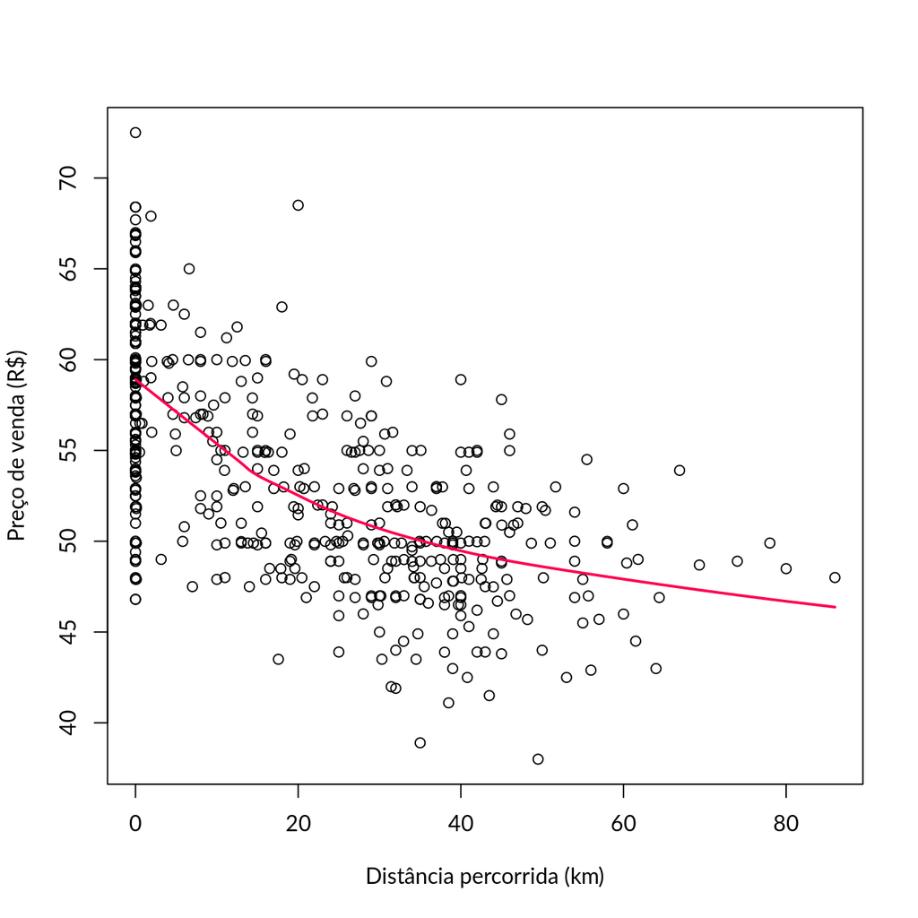

```r
# Adicionar uma linha de tendência suave.
plot(valor ~ km,
     data = dus2,
     xlab = "Distância percorrida (km)",
     ylab = "Preço de venda (R$)")
with(dus2, {
    lines(lowess(x = km, y = valor),
          lwd = 2,
          col = "#ff0050")
})
```

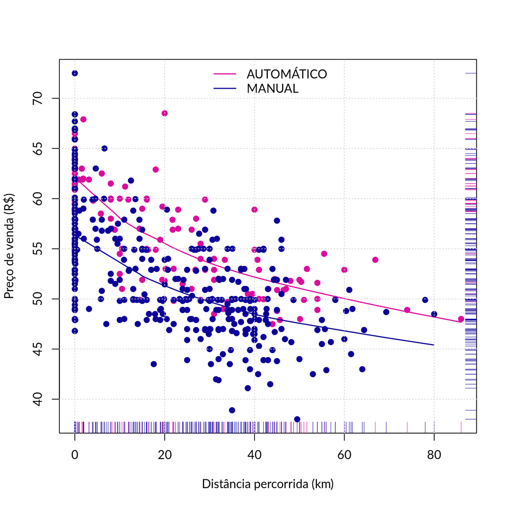

```r
# Usar cores diferentes para identificar o tipo de câmbio, com linhas
# de tendência e grid.

cols <- c("#db0d9d", "#0c0099")
levels(dus2$cambio)
# [1] "AUTOMÁTICO" "MANUAL"

plot(valor ~ km,
     data = dus2,
     type = "n",
     xlab = "Distância percorrida (km)",
     ylab = "Preço de venda (R$)")
i <- 0
by(dus2,
   INDICES = dus2$cambio,
   FUN = function(data) {
       i <<- i + 1
       with(data, {
           points(x = km, y = valor, col = cols[i], pch = 19)
           lines(lowess(x = km, y = valor),
                 col = cols[i],
                 lwd = 1.5)
           rug(km, side = 1, col = cols[i])
           rug(valor, side = 4, col = cols[i])
           invisible()
       })
   })
# dus2$cambio: AUTOMÁTICO
# NULL
# --------------------------------------------------------
# dus2$cambio: MANUAL
# NULL
legend("top",
       lty = 1,
       col = cols,
       legend = levels(dus2$cambio),
       lwd = 1.5,
       bty = "n")
grid()
```

O diagrama de dispersão é um dos gráficos mais fáceis de produzir pois não requer pré-processamento dos dados. Ou seja, o gráfico exibe todos os pares de pontos, diferente dos gráficos de barras que presentam o resultado de uma agregação dos dados: as frequências absolutas ou relativas.

Por outro lado, quando-se deseja destacar categorias usando cores ou símbolos, é necessário trabalho manual. Uma das principais vantagens da `lattice` e `ggplot2` é fazer isso de forma bem mais simples.

# 7 Gráfico para variável contínua e categórica

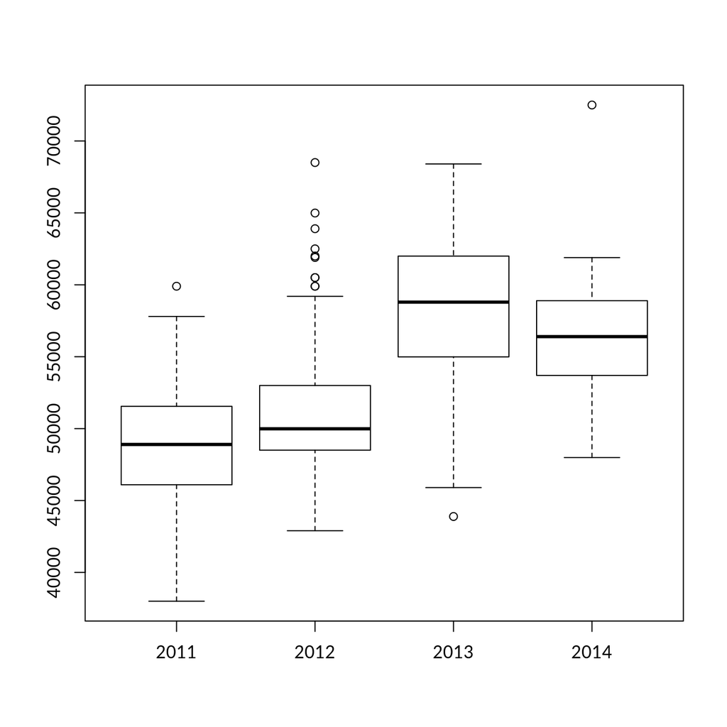

```r
#-----------------------------------------------------------------------

# Preço em função dos anos.
boxplot(valor ~ ano, data = dus)
```

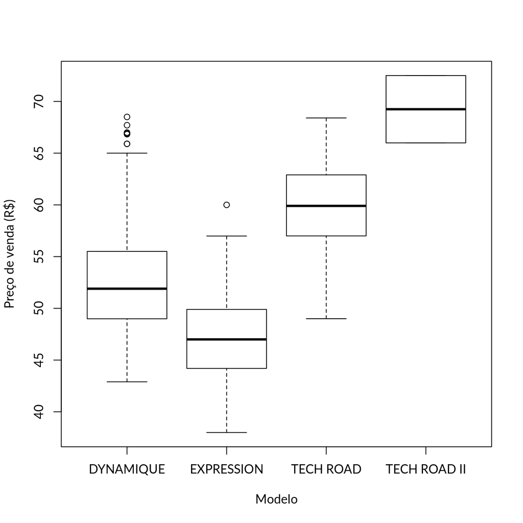

```r
# Edita níveis do fator.
levels(dus$cat)
# [1] " "              " DYNAMIQUE "    " EXPRESSION "   " TECH ROAD "
# [5] " TECH ROAD II "
levels(dus$cat) <- trimws(levels(dus$cat))
dus2 <- droplevels(subset(dus, cat != ""))
dus2 <- transform(dus2, valor = valor/1000, km = km/1000)

boxplot(valor ~ cat,
        data = dus2,
        xlab = "Modelo",
        ylab = "Preço de venda (R$)")
```

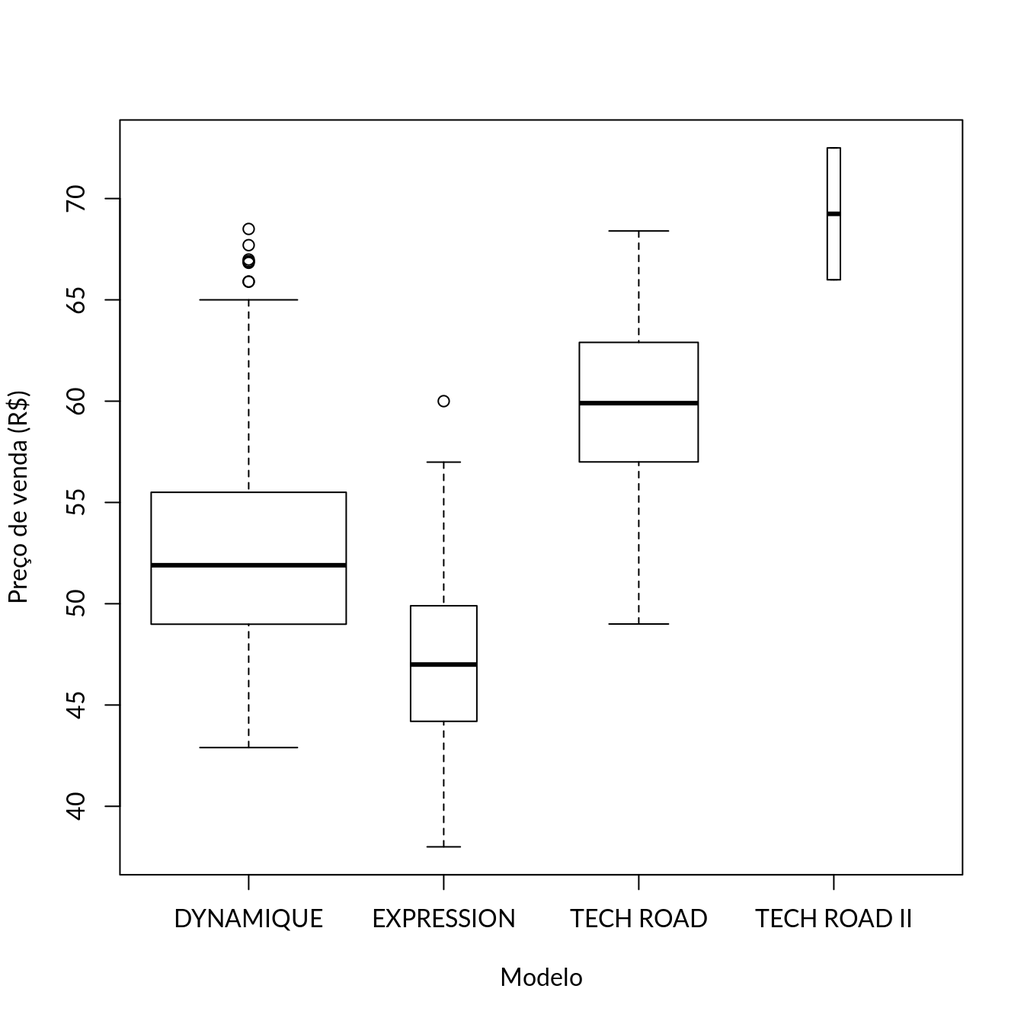

```r
# Larguras proporcionais à raiz da quantidade em cada grupo.
boxplot(valor ~ cat,
        data = dus2,
        varwidth = TRUE,
        pars = list(boxwex = 1),
        xlab = "Modelo",
        ylab = "Preço de venda (R$)")
```

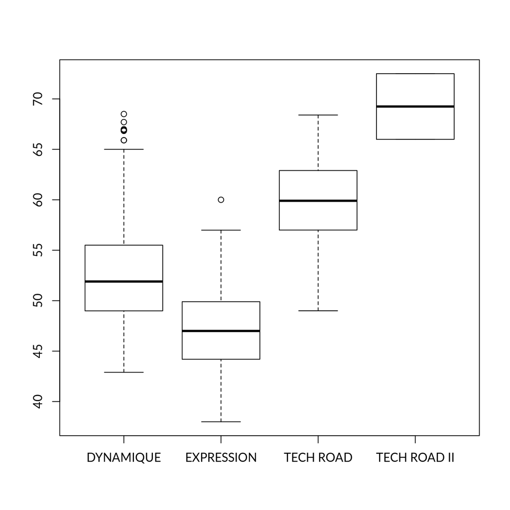

```r
table(dus2$cat)
#
#    DYNAMIQUE   EXPRESSION    TECH ROAD TECH ROAD II
#          442           51          164            2

# Indicação do valor da média.
mds <- with(dus2, tapply(valor, cat, mean))
mds
#    DYNAMIQUE   EXPRESSION    TECH ROAD TECH ROAD II
#     52.75835     47.34853     59.79432     69.24500

bp <- boxplot(valor ~ cat, data = dus2)
```

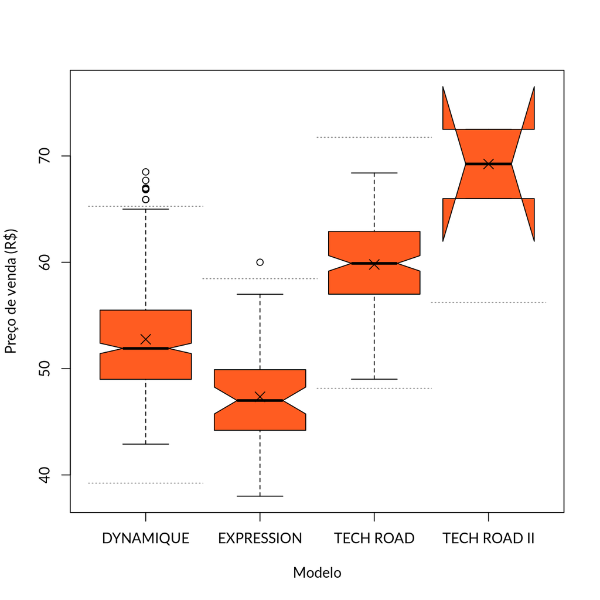

```r
bp
# $stats
#       [,1]   [,2]    [,3]   [,4]
# [1,] 42.90 38.000 49.0000 65.990
# [2,] 48.99 44.195 56.9995 65.990
# [3,] 51.90 46.999 59.9000 69.245
# [4,] 55.50 49.900 62.9000 72.500
# [5,] 65.00 56.990 68.4000 72.500
#
# $n
# [1] 442  51 164   2
#
# $conf
#          [,1]    [,2]     [,3]     [,4]
# [1,] 51.41075 45.7368 59.17201 61.97184
# [2,] 52.38925 48.2612 60.62799 76.51816
#
# $out
# [1] 65.90000 66.82871 68.50000 66.99000 65.90000 66.90000 66.90000 67.70000
# [9] 60.00000
#
# $group
# [1] 1 1 1 1 1 1 1 1 2
#
# $names
# [1] "DYNAMIQUE"    "EXPRESSION"   "TECH ROAD"    "TECH ROAD II"

# Amplitude interquartílica.
aiq <- bp$stats[4, ] - bp$stats[2, ]
l <- bp$stats[2, ] - 1.5 * aiq
u <- bp$stats[4, ] + 1.5 * aiq
i <- seq_along(u)

boxplot(valor ~ cat,
        data = dus2,
        notch = TRUE,
        col = "#ff5c21",
        xlab = "Modelo",
        ylab = "Preço de venda (R$)")
# Warning in bxp(structure(list(stats = structure(c(42.9, 48.99, 51.9,
# 55.5, : some notches went outside hinges ('box'): maybe set notch=FALSE
points(x = 1:nlevels(dus2$cat), y = mds, pch = 4, cex = 1.5)
segments(x0 = i - 0.5, x1 = i + 0.5, y0 = l, y1 = l,
         col = "gray50", lty = 3)
segments(x0 = i - 0.5, x1 = i + 0.5, y0 = u, y1 = u,
         col = "gray50", lty = 3)
```

O gráfico/diagrama de caixas e bigodes (box and whiskers) representa os 5 números de Tukey: mínimo, 1 quartil, mediana, 3 quartil e máximo. Alguns pontos são represetados além da extremidade do bigode porque ultrapassam a linha imaginária construída baseana na amplitude interquartílica (AIQ = 3 quartil - 1 quartil). A opção `notch = TRUE` faz um entalhe para representar o intervalo de confiança para a mediana, baseados na distribuição normal assintótica da mediana. Visite `?boxplot.stats` para mais detalhes.